# Multi-Agent Orchestration with tmux

# Multi-Agent Orchestration with tmux

**Source:** Screen-recorded YouTube tutorial (live terminal + browser demo) **Presenter:** Andy Devdan (IndyDevDan) **Runtime:** ~24m 11s **Figures:** 14 live-demo screenshots drawn from the recording (sampled at 1-second intervals)

## Introduction: The Real Constraint Is You and I

*[~0:00]*

What’s up, engineers? Andy Devdan here. We’ve got a couple of massive releases to cover. Of course, there is the brand new **Claude Opus 4.6**. It’s a fantastic model — what else is there to say? It’s beating all the benchmarks. You’ve already heard it, you’ve already seen it. But this is not what I want to focus on here.

The real big idea I want to cover with you today is **multi-agent orchestration**. The game on the field is changing. It’s no longer about what the models *allow* us to do. As of **Sonnet 4.5**, these models can do much more than you and I give them credit for — much more than you and I really know how to unlock.

The true constraint of agentic engineering now is twofold. It’s the **tools** we have available, and it’s **you and I** — our capabilities. It’s our ability to prompt-engineer and context-engineer the outcomes we’re looking for, and to build them into reusable systems — into powerful agentic layers that you and I can wield. The true limitation is you and I.

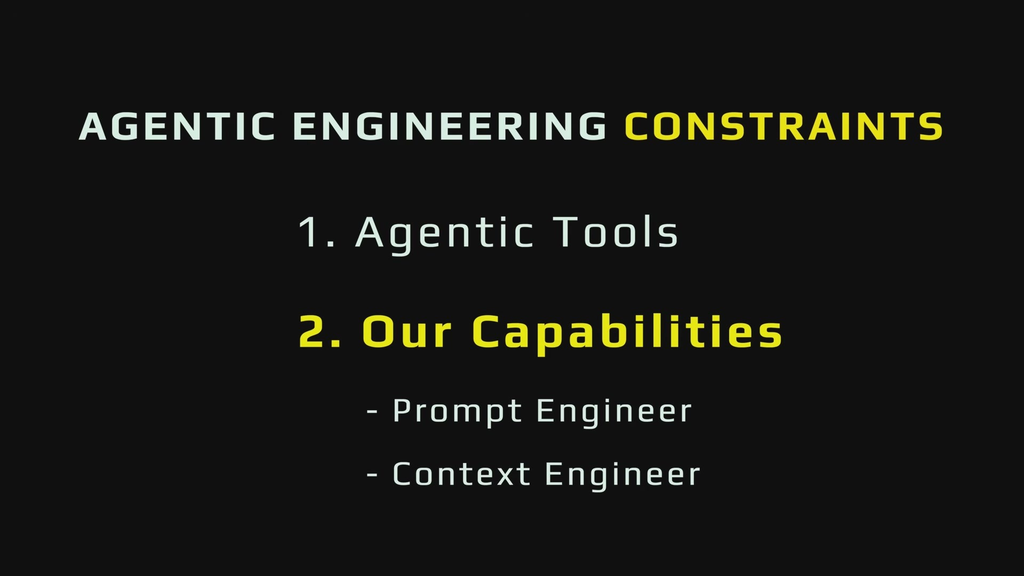

So let’s take another stab at improving what we can do. Front ends, back ends, scripts — it’s too simple for these models. So what I have here is **eight unique applications** that I had Claude Opus 4.6 create. I touched none of these, by the way — these are all one-shotted. I like to use **E2B**; use whatever you want. Agent sandboxes are very powerful.

But once again, that’s not exactly what I want to focus on. We’re going to use agent sandboxes as a playground to dive into two key big ideas: **multi-agent orchestration** and **multi-agent observability**. Once you put these two pieces together, you can do much more with your powerful Claude Code Opus 4.6 agent.

## Cracking Open the Terminal: Observability and tmux

*[~1:45]*

First things first, we’re going to crack open the terminal. If we create a new Claude Code instance, on our multi-agent observability you’ll see a new agent joining the session — we have that **SessionStart hook** captured. We have a rocket, and we’ve officially kicked off a new session. Close it, and you’ll see we get the **SessionEnd** event captured here.

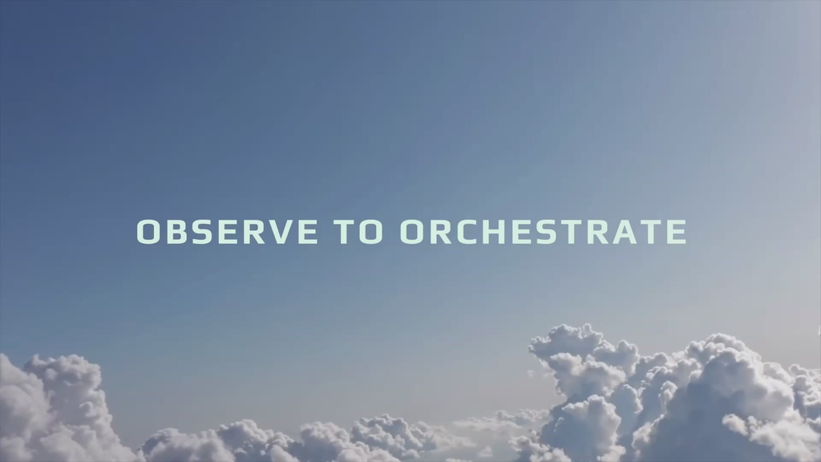

But before we touch our new multi-agent orchestration capabilities, we need to boot up Claude Code in a different way. Instead of opening it in a classic terminal, we’re going to use **tmux** — and that gives us some powerful capabilities, as you’ll see in a second.

I just want to make this super clear: I’m going to type `which cldyo` so you can see the exact command I’m running. We’re going to export the new Claude Code **experimental agent teams** feature — setting that flag to one enables the feature. So now we’re running Claude Code inside of a tmux session, and you can see we kicked off a brand new agent.

[figure not shown]

This is where things get interesting. If I type `ls`, these are the agent-sandbox directories. We’re going to have our agents investigate and break down how to set up these applications. So this is going to be our first agent team:

> Build a new agent team for each codebase in this directory. Have an agent summarize each one and how to set it up.

## The First Agent Team: Eight Agents, Eight Codebases

*[~2:48]*

What you’re going to see here is really extraordinary. You can see all of our events getting captured — observability is really important for knowing what you can do with your tools. We’re going to start streaming in all of our agent events, stuck to the bottom here.

The first thing our agent does is create a **task list** — we covered this in our previous video. What happens next is extraordinary: we’re in tmux, and tmux has **panes**. Our agent is now opening up a brand new pane for each sub-agent it wants to run.

[figure not shown]

Let me go full screen so we can really take a look at this. On the left, our primary agent set up the task list, created a team, and assigned a task to each member of the team. The status lines show the agent, the model — looks like we have **Haiku agents** here — and the context window. Our agents are going to figure out how to run and summarize each codebase.

[figure not shown]

## Specialized Agents That Finish

*[~4:20]*

If we hop back over here, all the panes are gone now. What happened? All of our agents finished their work. So we get out of full-screen mode, and it’s just our primary agent running. This is a really powerful capability of multi-agent orchestration: you want to spin up **specialized agents that do one thing extraordinarily well**. They focus on one task and then they finish.

Our primary agent is now putting together a summary of the work done by the eight agents — and take a look at the context window: we’ve only used **31%**. That means all of our other agents explored eight different codebases on their own context. And to be super clear, these are not just front ends — these are **full-stack applications**, every single one, fully built out and fully interactive. They were one-shotted by Opus.

[figure not shown]

And none of this matters if you can’t first trigger these features and prompt your primary agent to control these workflows. If you have no idea what’s going on under the hood — this is where vibe coders fall apart. They don’t actually know what’s happening. The engineers, the builders, and even the vibe coders who *do* know what’s going on under the hood can do so much more.

> This whole idea that engineers are going to be replaced by this technology, to me, is absurd. It’s because engineers are the best positioned to use agentic technology.

If I hit `Ctrl-B` then `[`, I’m in scroll mode now. The annoying thing about tmux is that it changes the controls a little bit. Scrolling up, we have summaries for every single agent-sandbox application stored in my local directory — a nice summary of all eight, and the primary agent knows how to spin them up.

[figure not shown]

## Pushing Further: Two Teams of Four

*[~6:09]*

Let’s push our multi-agent capabilities further. Let’s spin up new agent-sandbox instances with each one of these applications, and we’ll do it in **two teams**. A team of four will mount the first four applications, and another team of four will do the last set — because we have eight unique applications if we run `ls`.

Let’s prompt-engineer this properly. We start with the most important piece: **build a new agent team**. These are information-dense keywords that tell the agent we want a specific set of tools to execute. Then I’ll say *using agent sandboxes* — that’s my agent-sandbox skill — *use the `\reboot` command and mount one through four in their own agent sandbox. Be sure to set up every agent.*

> Part of my workflow when I’m doing rapid prototyping: I build it all in an agent sandbox, like E2B. And if I like one of the versions, I’ll copy it down locally — and I have prompts for that too.

[figure not shown]

We fire this off, and right away our observability system picks up the new **UserPromptSubmit** event. Our agent first runs the agent-sandbox skill, then the `\reboot` command skill so it understands what `\reboot` does, and then it kicks off the reboot for every directory. It creates that task list again — the task list is the centralized hub where everything gets kicked off from.

Now we’re kicking off our agent team. We have our primary agent kicking off the first agent, which then runs that skill. Every single agent has its own context window, so they all need to run the skill and the setup commands; you can see it running through the E2B setup process. And these are all **Opus 4.6 agents** now — all four running in parallel, each rebooting an application.

If we search our observability for our brand-new tools, you can see the new **task-list tools**: `task update`, `task`, and so on. This is the exact command that was run to kick off each sub-agent. Every one of our agents has its own context window, its own model, its own session ID, and its own unique name — `sbx-agent` one, two, three, and four.

Inside tmux I hit `Ctrl-B` then `←` to change my cursor position. I want the names of the sandboxes we didn’t kick off, so I’ll just ask the primary agent — it’s not doing anything right now, just waiting for events to come back: *list sandbox directories we didn’t kick off.* Sandbox agent number four has completed its setup and pinged a command back to our primary orchestrator agent.

While this runs, I’ll open up a new terminal to kick off the second team. We’re not going to do it in a flat window — we need tmux to get those multiple panes. So I run `tmux`, boot up Claude Code, and run that same prompt. I’m having trouble copying the directory names, so I’ll just ask my agents to do it for me: *copy the four sandbox directories to my clipboard* — it does a `pbcopy`. Then I paste, say “only post these four,” and kick it off.

> And I’m sure you noticed — if I scroll to the top, I’ve run out of my API usage for today on my Claude Max plan, so I’m on API billing. This is going to burn a hole in my wallet. Drop a like, drop a comment so the YouTube algorithm can pay for some of this API usage.

## Combining the Three Big Ideas

*[~12:00]*

So here’s that second team of agents doing a whole different set of work in a brand new window. If we go full screen, we have **two teams of agents working** and an observability system to trace the whole thing. They’re going to mount these applications — create a new E2B agent sandbox, upload the app codebase, install, and get everything set up as if it’s a brand new environment.

We’re combining several really powerful ideas here that we’ve been talking about week after week:

- **Multi-agent observability** — so we know what’s going on, and how to improve and understand our systems.
- **Agent sandboxes** — spaces to place our agents so they can do whatever they need without jeopardizing our local machine.
- **Multi-agent orchestration** — the new capabilities coming out of Claude Code, on top of a brand new ultra-powerful model that can run long-duration tasks.

We’re talking about long threads, big threads — handing off more and more work to our agents. That is the theme. How can you prompt-engineer and context-engineer with great, powerful models to get more engineering work done than ever, with confidence?

> We want to be building **systems of trust** with our agents. Scaling up the model always helps with this, but that’s not something we control — whenever the new model ships, whatever it costs, we are subject to that. What we *can* control is the great tooling we use alongside these capabilities.

To be clear, the agents are running on my device, but the work they’re doing operates *off* the device — they use their local agentic capabilities and skills, and then create and operate inside their own agent sandboxes.

## Opening the Apps and Iterating

*[~13:30]*

Our first team is all set up. Let’s open these up — I’ll move the existing sandbox windows onto my monitor, and they should open in this browser window. These sandboxes are going to be alive for 12 hours.

Here’s our “Agentic Support” app. It looks like we’re missing some data here, and missing data there. Let’s check the gallery — nice. So we did get some nice information, and we have our data here. We can continue to prompt to resolve these issues. Basically, our sandboxes were rebooted, but they didn’t reboot with the exact same data — or with any data — for a couple of applications. So I’ll have the agents do this work:

> I’ll stop this because the primary agent started trying to take over. *Spin up a new agent team to do this work for you. Give them all the context they need — skills, sandbox, the command.* I’m being super verbose with my prompt engineering there.

Our second team finished. Let’s open all four URLs in Chrome and drag them over. We have our **Mission Briefings** dashboard, our **portfolio** application to track our forecast, a **recipe** app, and an **ad dashboard** to see how our ads are performing. We got all the data for these — so all four worked. Love to see that. The two issues we had with the other codebases are getting resolved with our two-agent team. This is an iterative process: we want to be firing off ad hoc agent teams to perform specific sets of work.

[figure not shown]

## The Task System and Why It Matters

*[~16:09]*

In our previous video we talked about the **Claude Code task system**: you prompt your primary agent, and your primary agent creates a task list that an agent team operates on. This is a very powerful feature, taken to the next step with the multi-agent orchestration feature you can now tap into.

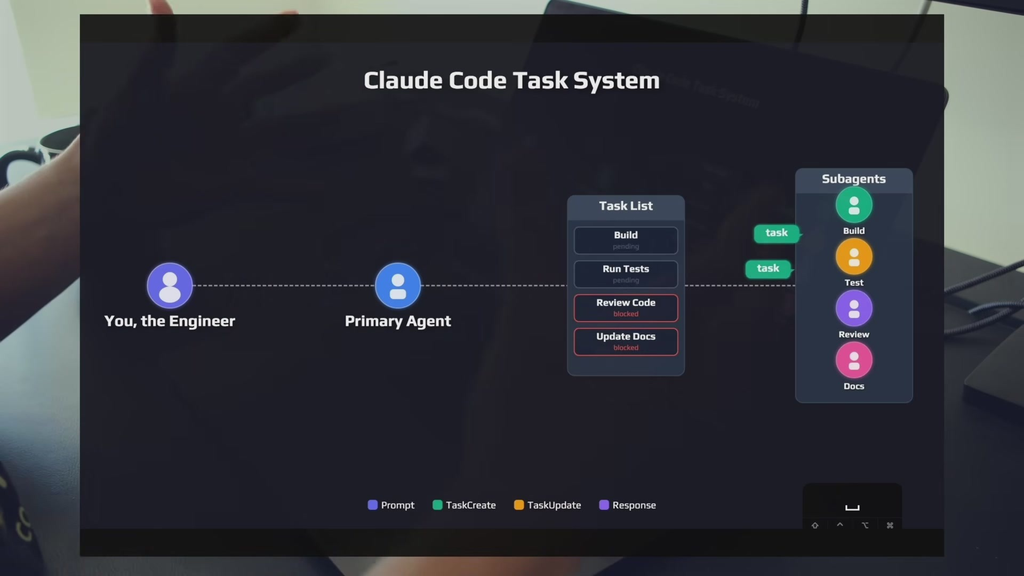

The idea here is really important. As you scale up the work you can do with your agents, it’s not just about a single agent, or a couple of agents, or even parallel agents. You want to be building **teams that communicate together**, all driven toward accomplishing one specific goal.

Think about building out a feature — that’s way too much work, especially as you enter real, legitimate production codebases. Building a full feature requires organization and communication. This new agent-orchestration feature lets us tap into that way of thinking.

## Deleting Agents Is Good Context Engineering

*[~17:00]*

Here’s what this feature looks like end to end: we create a team, we create tasks, we spawn agents, they all work in parallel, then they shut down, and then we delete the team. A really important aspect: **when the work is done, you want to delete the agents.** This forces a good pattern of context engineering, where you reset the context and start over.

So you can see the agent-shutdown process happening from our primary agent — the agents are shutting down, the tasks are gone, the panes are gone. And apparently this has fixed the issue: the database was intact, we restarted, both processes were down, so we should be good on those two applications.

Let’s refresh. Still not good there — that’s too bad. Let’s refresh here — this one loaded its data. Loading pull requests… still nothing there. So we have some issues. I don’t really care about these; you get the point. We got **six out of eight** sandbox environments spun up in brand new systems. To be transparent: here are the new environments and new URLs, and here are the old ones — these are actually different URLs, so they’re all unique agent sandboxes.

## Scaling Compute: 24 Sandboxes

*[~18:20]*

I have a bunch of these running right now. If I go to a terminal and pass in my skill, we’ll spin up a new agent — we always want to be operating on fresh instances. We don’t need tmux for this; it’s a single Claude Code instance. I’ll fire off my agent-sandbox skill and say *list all running sandboxes*. It validates my E2B key, and… there we go.

[figure not shown]

We have **24 sandboxes**, just to make it super clear how much compute we’re running in parallel. I think agent sandboxes are, and will be, a big, big trend as we scale up what our agents can do on our behalf. You’re seeing this with the whole Mac mini craze — as you can see in the background, I have a Mac mini, and I was a decent amount ahead of that trend, having my agents run in their own dedicated environment.

I have multiple sandbox environments: one like E2B operating purely in the cloud, and for more personal workflows where privacy is important, you can have agents run on your own local devices, like the local-agent bots everyone is adopting now. I have a skill and an agent that operate and manage all of these agent sandboxes at scale. This is going to be really important as you’re scaling your compute to scale your impact.

## The Core Four

*[~20:15]*

Here we looked at how to spin up teams of agents — and it all comes back to things we talk about on the channel all the time. All these fantastic new tools and capabilities coming out of the Claude Code team — there was a lot of engineering work put into this, big shout out to them. But underneath all of it is a concept we always discuss: **the Core Four — Context, Model, Prompt, Tools.** Everything boils down to that.

## The New Multi-Agent Toolset

*[~20:47]*

We saw all this work happen, and we saw our multi-agent system track all of it. So what are all the new available tools? There are roughly three categories that this new multi-agent orchestration system gives us: **team management, task management, and communications.**

[figure not shown]

`Task` has been around for a long time — that’s how you kick off an agent in parallel. But then we have all the new task-management tools: `TaskCreate`, `TaskList`, `TaskGet`, `TaskUpdate`. And the most important one of all is probably **`SendMessage`** — that’s how the agents were communicating.

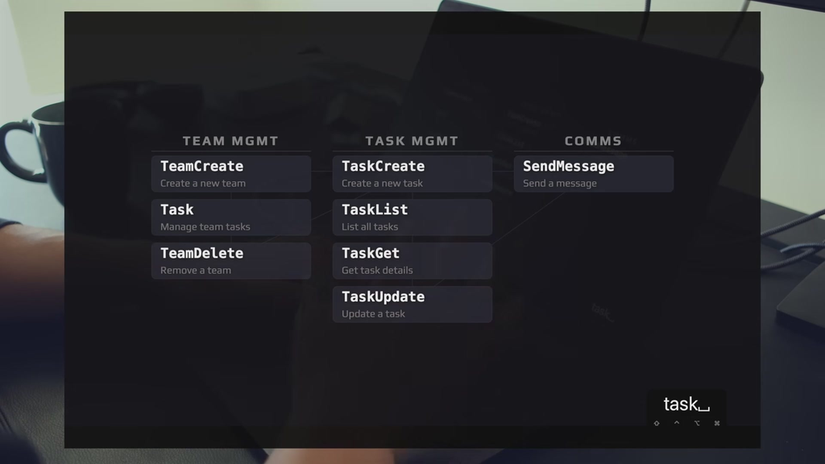

After they communicate and do all the work, this is the multi-agent orchestration workflow built up with this new tool: **create the team, create the tasks, spawn the agents, work in parallel, shut them all down, delete the team.** That’s the full workflow of the brand new Claude Code multi-agent capabilities.

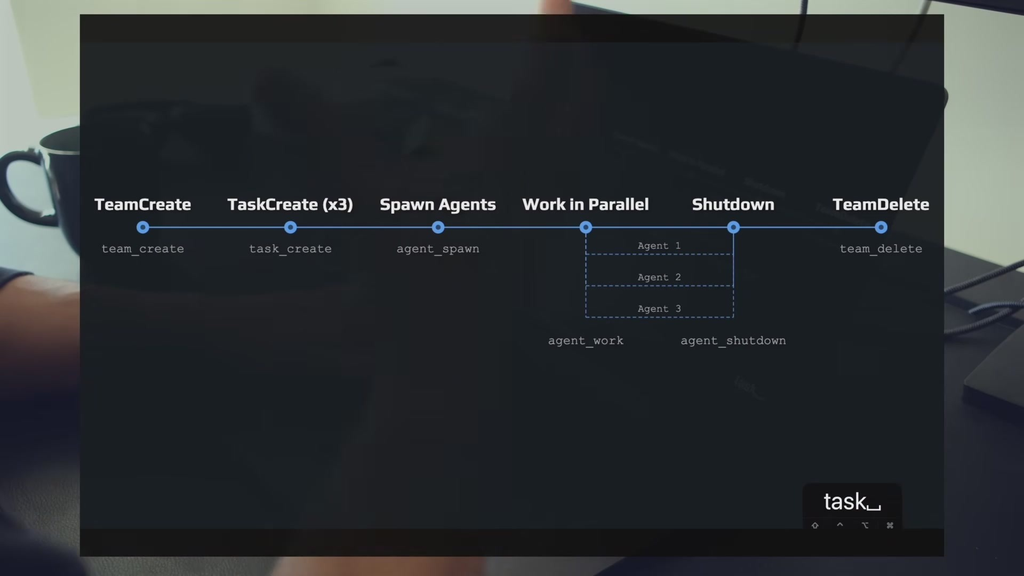

## The Engineer Is the Limitation

*[~21:44]*

With every new capability, every new feature out of Claude Code and all these agentic coding tools, every new model release — the question is always the same for you and me, the engineer with our boots on the ground, working with this technology every single day: **How can we understand the capabilities available to us to accelerate our engineering work?**

Models will improve, tools will change, and that means **you and I will always be the limitation**. So with every feature release, make sure you’re digging in and understanding what’s available, so you know what you can do.

> Every engineer is limited by their tools and their knowledge of their tools. That’s why multi-agent observability is super key. Throughout any point in this workflow, we can jump in, investigate, and see the communication and the tasks between the agents we kicked off.

## Closing

*[~22:50]*

I’m going to leave my multi-agent observability updated to support all these new tools — link in the description, along with a previous video and my agent-sandbox skill for you to play with.

If you’re interested in taking your agentic coding to the next level, check out **Tactical Agentic Coding** — my take on how to accelerate far past AI coding and vibe coding with advanced agentic engineering, so powerful your codebase runs itself. We’re seeing multi-agent orchestration come out of the Claude Code team; we’ve had working versions of it documented inside this course — inside the *agentic horizon* module — for months now. Thousands of engineers have already taken it and gotten great value.

We’re going to be covering multi-agent orchestration a lot as we move forward. It’s going to be a big trend because it lets us do what we always do on this channel: **scale our compute to scale our impact.**

> Thanks so much for sticking around. You know where to find me every single Monday. Stay focused and keep building.

## Key Takeaways

[output not shown]